```python
# 环境初始化
import pandas as pd
import numpy as np
import cufflinks as cf
import plotly
import matplotlib.pyplot as plt
import plotly.offline as py
from plotly.offline import init_notebook_mode, enable_mpl_offline, iplot_mpl
init_notebook_mode()
cf.go_offline()
```

# 动调长单保护第二期方案

## 动调封顶逻辑的现状

### 金额封顶

动调此前一直有59元的封顶逻辑，从2016年9月30号开始动调开始使用全国最高39元的封顶逻辑

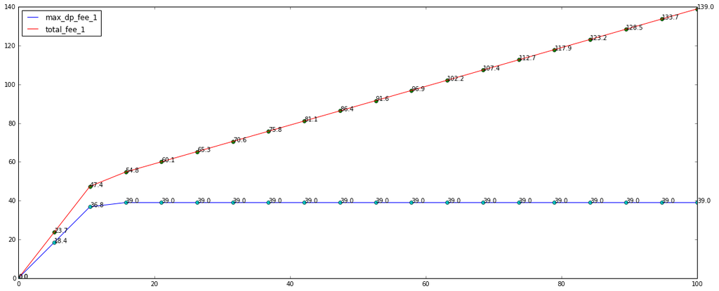

```python
%matplotlib inline

INTERVALS = 20
PRICE_CEIL_1 = 39 # 封顶金额39
TIMES_CEIL_1 = 3.5 #此时（2016-09-30），一些主干城市的最高封顶倍数还是3.5
MAX_PRE_TOTAL_FEE = 100 #最高预估价，方便画图
MIN_PRE_TOTAL_FEE = 0 #最低预估价

FIG_SIZE = (20,8)

x = np.linspace(MIN_PRE_TOTAL_FEE,MAX_PRE_TOTAL_FEE,INTERVALS) # 预估价向量
y_max = list(map(lambda y:min(PRICE_CEIL_1,TIMES_CEIL_1*y), x))
y_total = x+y_max

fig = plt.figure(figsize=FIG_SIZE)
plt.plot(x,y_max,label='max_dp_fee_1')
plt.plot(x,y_total,"o")
plt.plot(x,y_total,label='total_fee_1')
plt.plot(x,y_max,"o")
for idx in range(len(x)):
    plt.text(x[idx],y_max[idx],"%.1f"%(y_max[idx]))
    plt.text(x[idx],y_total[idx],"%.1f"%(y_total[idx]))
plt.legend(loc="upper left")
#iplot_mpl(fig)
```

### 倍数封顶

2016年国庆节之后，紧随最多39的封顶金额之后又添加了全国最多2.0倍的封顶逻辑，后根据各个城市的运营要求的不同会分城市调整

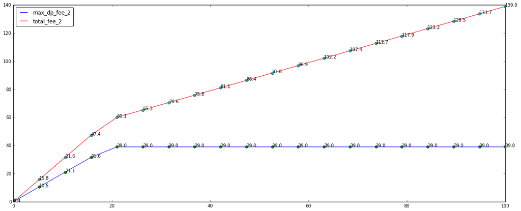

```python
TIMES_CEIL_2 = 2.0
y_max_2 = list(map(lambda y:min(TIMES_CEIL_2*y,PRICE_CEIL_1),x))
fig2 = plt.figure(figsize=FIG_SIZE)
plt.plot(x,y_max_2,label="max_dp_fee_2")
plt.plot(x,y_max_2,"o")
y_total_2 = x+y_max_2
plt.plot(x,y_total_2,label="total_fee_2")
plt.plot(x,y_total_2,"o")
for idx in range(len(x)):
    plt.text(x[idx],y_max_2[idx],"%.1f"%(y_max_2[idx]))
    plt.text(x[idx],y_total_2[idx],"%.1f"%(y_total_2[idx]))
plt.legend(loc="upper left")
```

### 长单保护

应城市运营的要求，2016年11月21日在北京上线了长单保护的封顶逻辑

### 长单保护一期

#### 目的

保护长单，尽量使得原价45以上的不动调，并且30以上的动调幅度不易过大

#### 注意事项

尽量避免倒挂：短单调价后反而比长单的单价高

#### 方案

描述：取固定价格（现在是以5元为步长采点），指定调价上线，直至为0 目标，理想的状态（之一）是（0~40）区间的凹函数，类似于：

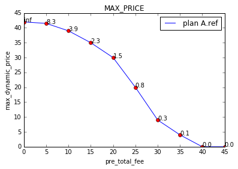

```python
# 公共变量
STEP = 5
PRICE_CEIL = 45
PRICE_FLOOR = 0
ll = int((PRICE_CEIL-PRICE_FLOOR)/STEP)
x = np.linspace(PRICE_FLOOR,PRICE_CEIL,ll+1)

#画布设置
plt.figure()
plt.xlabel("pre_total_fee")
plt.ylabel("max_dynamic_price")
plt.title("MAX_PRICE")

#                0      5     10    15   20      25    30   35   40   45   50
y_A_ref = np.array([42.0, 41.5, 39.0, 35.0, 30.0, 20.0, 9.0, 4.0, 0.0, 0.0])
for idx in range(len(y_A_ref)):
    if x[idx] == 0:
        plt.text(x[idx],y_A_ref[idx],"inf")
    else:
        plt.text(x[idx],y_A_ref[idx],"%.1f"%(y_A_ref[idx]/x[idx]))
plt.plot(x,y_A_ref,label="plan A.ref")
plt.plot(x,y_A_ref,"ro")
#
plt.legend(loc="upper right")
plt.show()
```

上面的配置如下（预估价：最大调价金额）：0:42.0, 5:41.5, 10:39.0, 15:35.0, 20:30.0, 25:20.0, 30:9.0, 35:4.0, 40:0.0, 45:0.0

#### 问题

符号说明：设$a_1,a_2$表示两个预估价，$b_1,b_2$表示起对应的调价金额

退而求其次，这里尽量保证在相同倍数下的调价不会出现倒挂的现象

```
1#BigOrderProtect 3 100.0 1 500.0 0.0 50.0 25.0 25.0 25.0 0.0
1#BigOrderProtect 7 100.0 1 500.0 0.0 50.0 25.0 25.0 25.0 0.0
```

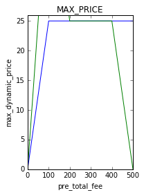

```python
%matplotlib inline

import numpy as np
import matplotlib.pyplot as plt
from scipy import interpolate
# 公共变量
STEP = 100
CEIL_TIMES=0.5
CEIL_PRICE=25
PRICE_CEIL = 500
PRICE_FLOOR = 0
DENSE = 0
ll = int((PRICE_CEIL-PRICE_FLOOR)/STEP)
x = np.linspace(PRICE_FLOOR,PRICE_CEIL,ll+1+DENSE)
#画布设置
plt.figure()
plt.subplot(1,2,1)
plt.xlabel("pre_total_fee")
plt.ylabel("max_dynamic_price")
plt.title("MAX_PRICE")
#坐标系
plt.xlim(PRICE_FLOOR,PRICE_CEIL)
plt.ylim(PRICE_FLOOR,CEIL_PRICE+1)
#动调现在的封顶逻辑
y_real = CEIL_TIMES*x
y_real[y_real>CEIL_PRICE]=CEIL_PRICE
plt.plot(x,y_real,label="current(min(39 or 2 times))")
#长单保护的曲线
y_A = np.array([0.0,50.0,25.0,25.0,25.0,0.0])
plt.plot(x,y_A,label="linear(truncate)")
#y_A_real = np.array([min(y_A[i],y_real[i]) for i in range(ll+1+DENSE)])
config_str = ""
for idx in range(len(x)):
    config_str = config_str + (" %.1f"%(y_A[idx]))
print("1#BigOrderProtect 3 %.1f 1 %.1f%s"%(STEP,PRICE_CEIL,config_str))
print("1#BigOrderProtect 7 %.1f 1 %.1f%s"%(STEP,PRICE_CEIL,config_str))
plt.show()
```

## 二期方案

由于一期的服务上线比较仓促，代码写得不够灵活，所以二期主要从以下几个方面进行改造

### 支持最小不调价金额的配置

由于一期针对的是北京上线，所以写死了45的最小不动调金额

#### 一期的配置文件如下

city_id#MaxDynamicPrice product_id hour if_use_times min_no-dp_price [pre_total_fee max_dp_price ...] 1#MaxDynamicPrice 3 0 0 45.0 0.0 27.0 5.0 24.0 10.0 21.0 15.0 18.0 20.0 15.0 25.0 12.0 30.0 9.0 35.0 6.0 40.0 3.0 45.0 0.0

### 支持直线外的不同曲线

直线作为一个临时的方案，不是长久之计，希望支持多种曲线，可针对不同城市配置 现在对曲线做如下约定： 每个采样点之间（step内）：使用一阶差值（线段）来近似

### 支持局部区域的封顶逻辑

局部区域通过地理围栏实现(最终会获得一个围栏的ID，记为FENCEID)

针对每一个围栏ID有如下的配置（由运营的同学配置）：

FENCEID product_id distinct isRegular start_time("201611212100") end_time("201611220200") max_price max_times

上述配置的开关由start_time和end_time来实现，其中若"start_time>end_time||end_time < current_time" 都可以使得配置不生效

isRegular值为ON，且当起点和终点的日期相同的时候，表示每天的该时间段都会执行该逻辑

允许一个FENCEID有多条配置，如配置不同的时间段，则使用distinct来区分

## 三期方案

长单保护三期方案准备把：倍数封底，金额封顶，定价，长单保护收敛到一个地方，并统一命名为订单保护

### 主要改动点

- 特征仅支持金额配置（其它形式都可以转化为金额）
- 维度：区域（城市）+产品线+订单类型+封顶类型
  - 订单类型：实时单、预约单、拼车单、快车不同车型
  - 保护类型：订单保护，定价
- 格式上重新采用：（point,price）...的形式，以支持不同区间段（不定长）的配置:$y=f(x),where\ y=price,x=point$
- 依然采用线性差值的来拟合

#### 三期配置文件形式如下

area_id product_id order_type protect_type switch option [pre_total_fee max_dp_price ...]

- 一般area_id=city_id#OrderProtect
- option为扩展预留，现在等于“NULL”字符串，并约定option!="NULL"的时候使用逗号","分割其中的字段，且构成key=value形式
- city_id=0的时候表示默认配置，switch=["ON"|"OFF"]表示这条配置是否生效
- (pre_total_fee max_dp_price]为左开右闭的区间